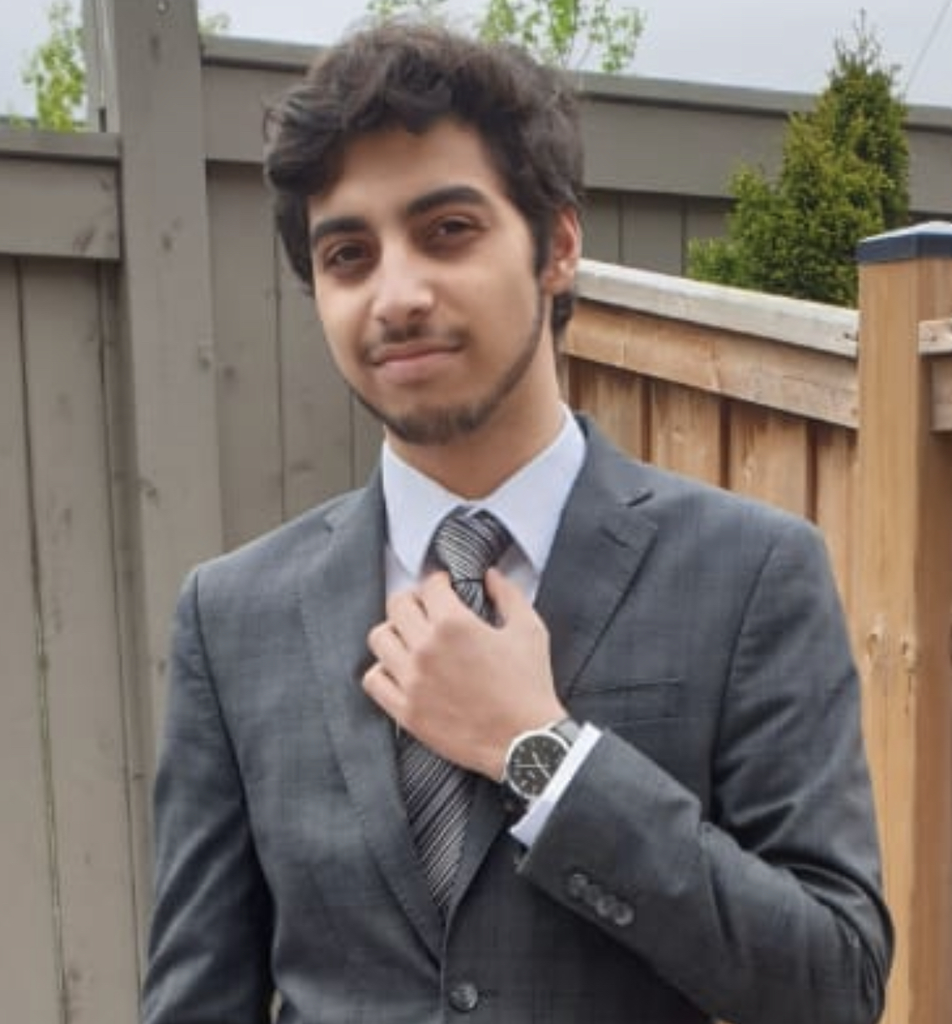

# Rayhan Walia

## About Me

My name is Rayhan Walia, and am currently a third-year student at the University of Toronto; with a double-major in physics and statistics. These fields define my character, and my interests; into who I am today. University has allowed me to transform from someone who had a general interest in a subject, to someone who has a good understanding of what to do with their life. This is a very powerful transformation, which is why most students continue onto university (post-secondary education). From this experience, I have come to the (temporary) conclusion that I am most interested in the analysis of data; whether it be related to experimental physics or statistics. Conducting experiments, surveys; and finally recording the measured data is what I have come to thoroughly enjoy.

Outside of school, I co-host a podcast, named the Math & Physics Podcast (linked above, under Website); where we discuss subjects of that matter. We have interviewed many professors and researchers from around the globe; to help spread our love for the sciences. I am also engaged in playing squash, the guitar, going to the gym, and other activities to pass my time.

## Education

**University of Toronto** | Toronto, ON

BSc in Physics and Statistics | September 2019 - present

**Richmond Hill High School** | Richmond Hill, ON

Diploma | September 2016 - June 2019

## Academic Experience

**Co-host of the Math & Physics Podcast** | May 2020 - Present

This experience has been one of the most joyful and interesting ones of my life. Over 2 years ago, I was unaware of podcasts, until a friend brought it up. 2 years later, we have had tens of guests, from all over the world; ranging from professors at universities, directors of research labs, to popular science content creators. With hundreds of thousands of downloads on our episodes, it is amazing how many people we inspire just by talking. We have had people email us, telling us how they have switched their career path, or have been re-inspired to go back to school, because of the podcast. This is something I could have never imagined myself doing over two years ago, and I am grateful for getting it started, and keeping it going!

**Research w/ Professor Dr. Rastgoo at York University** | May 2021 - September 2021

This was my first highly theoretical position, where a teammate and I were tasked with computing equations of motion of space-time around black holes; with the theory of loop quantum gravity. In the end, I wrote a paper summarizing the results; all of which taught me the hardships, struggles, as well as enjoyment of high-level theoretical physics.

**President of Astronomy & Astrophysics Club** | Richmond Hill High School | 2017-2019

Being the president of this club; I would organize ‘lectures’ that I would then present to the members, every week, on a new subject. Through this, I learned that I love to teach and help others, especially ones who are interested in similar subjects to me.

**Co-op Research** | York University | September 2017- February 2018

In this project, a teammate and I were tasked with experimentally measuring the differential (varying) rotation of the Sun, via utilizing the telescope available at the university. This experience was one I had at an early age and was very helpful in propelling me into astronomy. Since the very beginning, when I found out this was a possible position in my high school co-op program; I had been intrigued to try it. Am I glad I did! In the end, I was given the opportunity to present to the Astronomy and Physics clubs; on Einstein’s field equations and gravitational waves, talking about the recent discovery of gravitational waves. This was a great opportunity, as I had students from all over the university, part of the clubs, listen to me talk; when I was just 16!

## Work Experience

**Life Insurance Agent** | American Income Life | May 2021 - October 2021

For this position, I studied and obtained an official life insurance license, which taught me a lot about a subject I wasn’t even really aware of. Though this experience was quite different from the path I wish to take, it opened my eyes to the variety of options available. I was always interested in selling, just never knew it would be life insurance contracts!

**Sales Specialist** | Best Buy | July - September 2018

Being my first job, it was something I always loved, and frankly, knew a lot about; technology. This is where I discovered my love for selling since I would be so happy when a confused customer would come into a store looking for, “a computer” (as they would say), and leave with the exact one they required.

## Awards

**Dean’s List Scholar** | University of Toronto | 2021

**Later Life Learning Award** | Innis College @ University of Toronto | 2021

**Greg Wilkonson Award for Passion for Physics** | Richmond Hill High School Graduating Award | 2019